# Lecture 03: Inference in Logistic Regression

Module on Logistic Regression

# Lecture Goals

- Inference for Logistic Regression
- The idea of Deviance
- Likelihood Ratio Test & Pseudo $R^2$
- Prediction in Logistic Regression

# Working Data

The Youth Risk Behavior Surveillance System (YRBSS) is a public health initiative by the Center for Disease Control and Prevention (CDC) that monitors six key categories of health-risk behaviors among high school students. The YRBSS is conducted biannually in the spring semester and has been conducted regularly since 1991. We will look at a subset of the survey from 2023.

Specifically, we will look to determine if demographic variables are associated with wether a high school was bullied on school property in the preceding 12 months.

[figure not shown]

**Sources:** Data: (Centers for Disease Control and Prevention 2024). Concept and Clipart: (Brener et al. 2024).

```r
yrbss <- read_csv("https://tjfisher19.github.io/data/cdc_yrbss_2023.csv",
                  show_col_types=FALSE)
names(yrbss)
```

```
[1] "Age"               "Sex"               "Grade"
[4] "Height"            "Weight"            "Bullied_at_School"
```

Here, the **response variable** of interest is the character variable `Bullied_at_School` dictating if the student “Yes” has been bullied at school in the past year or “No”, they have not been bullied.

There are multiple **predictor variables** available in this data. In the previous lecture we focused on Height (m) and Grade but today we will explore the others.

## Data Handling

To ensure the model is fit correctly (categorical or logical response variable is required for the `glm()` function) and for better interpretation (order of Grade levels), we perform some data handling.

So we need to modify the response into a proper variable type. We also categorize the `grade` variable.

```r
yrbss <- yrbss |>
  mutate(Grade = factor(Grade,
                        levels=c("9th grade", "10th grade", "11th grade", "12th grade") ),
         Bullied = Bullied_at_School=="Yes")
```

## Fitting the main effects Model

We begin by fitting a full main effects logistic regression model. Recall some key elements from the previous lecture; here, $p=P(\text{Student was Bullied})$ is the variable of interest. We are fitting the model:
$$\log\left(\frac{p}{1-p}\right) = \beta_0 + \beta_1 X_1 + \ldots + \beta_k X_k$$
where the $X_k$ variables are the various predictors based on the variables `Age`, `Sex`, `Grade`, `Height` and `Weight`.

```r
full_yrbss_fit <- glm(Bullied ~ Age + Sex + Grade + Height + Weight,
                      data=yrbss,
                      family=binomial(link="logit"))
```

In the previous lecture we discussed how to interpret the logistic regression coefficients:

```r
coefficients(full_yrbss_fit)
```

```
             (Intercept)          Age13 years old          Age14 years old
             2.517923409             -3.063163935             -2.874243476
         Age15 years old          Age16 years old          Age17 years old
            -2.771126865             -2.773798039             -2.724409004
Age18 years old or older                  SexMale          Grade10th grade
            -2.507866813             -0.471487733             -0.333368536
         Grade11th grade          Grade12th grade                   Height
            -0.572946986             -0.899600570             -0.590077147
                  Weight
             0.006707037
```

Today, we will learn how interpret the output provided by the `summary()` function.

```r
summary(full_yrbss_fit)
```

```
Call:
glm(formula = Bullied ~ Age + Sex + Grade + Height + Weight,
    family = binomial(link = "logit"), data = yrbss)

Coefficients:
                          Estimate Std. Error z value Pr(>|z|)
(Intercept)               2.517923   1.183296   2.128  0.03335 *
Age13 years old          -3.063164   1.283927  -2.386  0.01704 *
Age14 years old          -2.874243   1.110852  -2.587  0.00967 **
Age15 years old          -2.771127   1.109960  -2.497  0.01254 *
Age16 years old          -2.773798   1.110144  -2.499  0.01247 *
Age17 years old          -2.724409   1.111288  -2.452  0.01422 *
Age18 years old or older -2.507867   1.114168  -2.251  0.02439 *
SexMale                  -0.471488   0.050784  -9.284  < 2e-16 ***
Grade10th grade          -0.333369   0.063984  -5.210 1.89e-07 ***
Grade11th grade          -0.572947   0.091962  -6.230 4.66e-10 ***
Grade12th grade          -0.899601   0.119176  -7.549 4.40e-14 ***
Height                   -0.590077   0.268764  -2.196  0.02813 *
Weight                    0.006707   0.001159   5.785 7.27e-09 ***
---
Signif. codes:  0 '***' 0.001 '**' 0.01 '*' 0.05 '.' 0.1 ' ' 1

(Dispersion parameter for binomial family taken to be 1)

    Null deviance: 17622  on 17604  degrees of freedom
Residual deviance: 17254  on 17592  degrees of freedom
AIC: 17280

Number of Fisher Scoring iterations: 4
```

Overall the output has similarities to the `summary()` output when we fit a linear regression model. Here, there are a few differences.

**Note**

The bottom line of the output is the `Number of Fisher Scoring iterations`. This corresponds to the number of numerical iterations needed to find a Maximum Likelihood Estimate for the model. The details of this metric are outside the scope of this class. Typically the Fisher Scoring iterations should be a single digit number. Higher number may indicate you have a poorly defined model.

# Deviance

The `summary()` output includes two lines that reference `deviance`. The specifics are outside the scope of this class but we take a moment to introduce the main idea: in short, **deviance** can be considered a *generalization* of *error*.

To understand its purpose, let $Y_i$ be the variable indicating if student $i$ was bullied. The values of $Y_i$ are Yes/No or True/False. Now consider the equation for the sum of squares total used in the calculation of the sample variance, which calculates the squared error between an observation and the sample mean:
$$SST = \sum_{i=1}^n\left(Y_i - \bar{Y}\right)^2$$

- What would $\bar{Y}$ mean here?
  - How can you find an ‘average’ of yes and no?
- What would $(Y_i - \bar{Y})$ measure exactly?
  - How do you compare a yes or no to an average (if you could define it)?

None of these terms are well-defined in the context of a categorical response variable. The **deviance** is a measure that calculates the *error* of a fitted model. More specifically, it compares the quality of the fitted model to a theoretical *perfect model* (also known as a saturated model) – wherein the perfect model would have zero error. This calculation provides a mechanism to gain some insight into the variability of the data and how much is being explained by the model. In the `summary()` output two measures of deviance are provided:

- The `Null deviance` provides the total deviance in the response variable when nothing has been modeled (an intercept only model) – think of this as an analog to $SST$.
- The `Residual deviance` is the remaining deviance after fitting the specified model – this is essentially an analog of $SSE$.

The difference between these two terms describes how much of the total deviance is being explained by the model. In the example above, 17621 - 17254 = 367.8 of the deviance is explained by the model.

# Whole-model test

When covering ANOVA and Regression, we discussed that the whole model $F$-test works by decomposing the total variance of the response into the part explained by the model and an unexplained part. We tested if the *explained* part was large enough to justify the model.

The description outlining deviance provides a GLM analog. A test can be performed to determine if the amount of deviance explained by the model is substantial enough to determine if the model significantly predicts the parameter of interest. Thus, we can test if the logistic model with Age, Sex, Grade, Height and Weight significantly predicts the probability a student had been bullied in the previous year.

Unfortunately, this test is not directly included in the R output but can be performed by comparing a fitted model to a “null model” or intercept-only model. The model’s significance is assessed with a likelihood ratio test (LRT).

The LRT can be used to test the significance of individual predictors (even categorical predictors with multiple levels), sets of predictors (like the reduced $F$-test from earlier this semester), or the “whole-model” $F$-test. LRT bridge the gap from regression modeling to other areas of statistics.

Here, the LRT is used similarly as the “whole-model $F$-test” from linear regression. In a logistic regression setting, we first need to fit a null model with only an intercept term.

```r
null_yrbss_fit <- glm(Bullied ~ 1,
                      data=yrbss,
                      family=binomial(link="logit"))
```

We then compare the two models using the `anova()` function.

```r
anova(null_yrbss_fit, full_yrbss_fit)
```

```
Analysis of Deviance Table

Model 1: Bullied ~ 1
Model 2: Bullied ~ Age + Sex + Grade + Height + Weight
  Resid. Df Resid. Dev Df Deviance  Pr(>Chi)
1     17604      17622
2     17592      17254 12   367.84 < 2.2e-16 ***
---
Signif. codes:  0 '***' 0.001 '**' 0.01 '*' 0.05 '.' 0.1 ' ' 1
```

The output looks similar to when fitting linear regression except:

- Instead of sum of squares, deviance values are now reported.
- The $F$-statistic is replaced by a `Deviance` term which is a **Likelihood Ratio Test** $\chi^2$ statistic (Chi-square).
- The $p$-value is now a Chi-square test $p$-value.

With a $\chi^2$ value of 367.84 on 12 degrees of freedom, $p$-value$\approx 10^{-16}$, we have overwhelming evidence that the model predicts the log odds a student has been bullied in the preceding year.

**Note**

Likelihood Ratio Test (LRT) are a general approach to performing hypothesis test in Statistical Modeling. In fact, most of the hypothesis covered in this course and Introductory Statistics are special cases of Likelihood Ratio Tests.

The Chi-square distribution connects to the Normal distribution and $F$-distribution used earlier in this course. Further details on the $\chi^2$ and LRT are covered in STA 401 and STA 462.

# Pseudo R-squared

Recall from regression that the equation for the Coefficient of Determination, or $R^2$, is
$$R^2 = 1 - \frac{SSE}{SST}$$

We no longer have the terms $SSE$ and $SST$, but we do have deviance measures that are similar. We can use those to compute a Pseudo-$R^2$ value as follows:
$$\text{Pseudo}~R^2 = 1 - \frac{\text{Residual Deviance}}{\text{Null Deviance}}$$

In our working example, the Pseudo $R^2$ is 1 - 17254.1 / 17621.9 = 0.021. So the model reduces about 2.1% of the deviance in the proportion of students who were bullied in the previous year.

**Note**

The details are outside the scope of this class, but Pseudo R-squared doesn’t have the same interpretation as the traditional coefficient of determination.

When applied to logistic regression this Pseudo R-square value will often times be small. In fact, a Pseudo R-squared of 20% to 40% suggest a very good fit.

It is typically used as a tool to assess if the model is a helpful fit, rather than a metric to explain how powerful the model is.

**Note**

This particular Pseudo R-squared value is also called the **Deviance $R^2$** or McFadden’s $R^2$. There are other measures of Pseudo R-squared used in Logistic Regression that have different interpretations and properties.

## Goodness-of-fit

The residual deviance in the model and its degrees of freedom can also be used as a quick check for the appropriateness of the model. If the logistic regression chosen is appropriate, than the Residual Deviance $\approx$ the degrees of freedom. This is typically checked by looking at the ratio:
$$\frac{\text{Residual Deviance}}{\text{Degrees of Freedom}}$$
and comparing it to the value of one. When this ratio greatly exceeds 1 this is known as **overdispersion** and suggests a logistic regression model is likely not appropriate.

In our working example:

```r
full_yrbss_fit$deviance
full_yrbss_fit$df.residual
```

```
[1] 17254.11
[1] 17592
```

with a ratio of

```r
full_yrbss_fit$deviance/full_yrbss_fit$df.residual
```

```
[1] 0.9807927
```

which is approximately 1; suggesting a good model fit.

# Testing model terms/components

Much of the same tests used to analyze the model coefficients in regression can be done in logistic regression as well. We step through the different procedures.

## Tests of individual predictors

**Wald z-tests.** In the `summary()` output, a $Z$-test for the conditional significance of each of the predictor variable is provided. These are similar to the conditional $t$-test from regression and can be interpreted the same way.

**Likelihood Ratio Chi-Square tests (preferred).** The Wald test is known to be statistically conservative (less Type I errors than is accepted). A preferred test, and much more flexible, is the LRT Chi-Square test (the same one used in the `anova()` output). To get LRT tests of individual predictors in your logistic regression model, we can either perform model comparison (using `anova()`) or use the `drop1()` function with the option `test="LRT"`:

```r
drop1(full_yrbss_fit, test="LRT")
```

```
Single term deletions

Model:
Bullied ~ Age + Sex + Grade + Height + Weight
       Df Deviance   AIC    LRT  Pr(>Chi)
<none>       17254 17280
Age     6    17273 17287 18.863  0.004401 **
Sex     1    17341 17365 87.138 < 2.2e-16 ***
Grade   3    17314 17334 59.967 5.974e-13 ***
Height  1    17259 17283  4.819  0.028142 *
Weight  1    17287 17311 32.589 1.138e-08 ***
---
Signif. codes:  0 '***' 0.001 '**' 0.01 '*' 0.05 '.' 0.1 ' ' 1
```

The output is similar to the `summary()` output except now the `Age` and `Grade` variables are being treated as one input for inference and the test statistic is a $\chi^2$ LRT.

We need to interpret these results just like the conditional $t$-test from regression:

- When a model includes `Sex`, `Grade`, `Height` and `Weight`, the addition of the variable `Age` significantly improves ($p$-value$= 0.0044$) the prediction of the log-odds a student has been bullied in the past year.
- When a model includes `Age`, `Grade`, `Height` and `Weight`, the addition of the variable `Sex` significantly improves ($p$-value$\approx 10^{-16}$) the prediction of the log-odds a student has been bullied in the past year.
- and so on …

**Coding Note**

When calling the `drop1()` function, we must specify `test="LRT"`. Otherwise it will report how the AIC values change when you drop a variable – helpful for model selection but not for inference.

**Coding Note**

The function `drop1()` was introduced in Linear Regression Lecture 05 as a “Coding Note”. In regression it can be used to perform conditional $F$-tests for each of the predictor variables (that is, special reduced model $F$-tests).

## Reduced-model tests

The LRT can be used to perform an analogous result to the reduced model $F$-test. Suppose we wished to test if the variables `Height` and `Weight` can be removed from the full main effects model, this is done with a reduced model $\chi^2$ test:

```r
## First, first the reduced model
reduced_yrbss_fit <- glm(Bullied ~ Age + Sex + Grade,
                         data=yrbss,
                         family=binomial(link="logit"))

## Now the chi-square test using the anova() function
anova(reduced_yrbss_fit, full_yrbss_fit)
```

```
Analysis of Deviance Table

Model 1: Bullied ~ Age + Sex + Grade
Model 2: Bullied ~ Age + Sex + Grade + Height + Weight
  Resid. Df Resid. Dev Df Deviance  Pr(>Chi)
1     17594      17287
2     17592      17254  2   32.604 8.322e-08 ***
---
Signif. codes:  0 '***' 0.001 '**' 0.01 '*' 0.05 '.' 0.1 ' ' 1
```

With a $\chi^2$ statistic of 32.604 on 2 degrees of freedom ($p$-value $\approx 10^{-8}$), we have evidence that the addition of Height and Weight significantly improves the prediction of the log-odds of whether a high school student has been bullied in the past year compared to a model with just age, biological sex and grade level. So in short, no, we cannot remove all two variables.

## Confidence intervals

We can also find confidence intervals for our estimated $\beta$-parameter values:

```r
confint(full_yrbss_fit)
```

```
                                2.5 %       97.5 %
(Intercept)               0.476276996  5.564016511
Age13 years old          -6.243477549 -0.830661166
Age14 years old          -5.843638503 -1.013380308
Age15 years old          -5.739538361 -0.912274511
Age16 years old          -5.742291521 -0.913898652
Age17 years old          -5.694034430 -0.861264285
Age18 years old or older -5.480514058 -0.637464275
SexMale                  -0.571170293 -0.372088935
Grade10th grade          -0.458883615 -0.208037396
Grade11th grade          -0.753259333 -0.392736844
Grade12th grade          -1.133377511 -0.666170565
Height                   -1.116860931 -0.063264180
Weight                    0.004424793  0.008970494
```

It is **very important** to consider the interpretation of confidence intervals in logistic regression. These are confidence intervals for the coefficients in the model **in terms of the log odds**.

- So for a 12 year or younger female student who is 0 meters tall and weighs 0 kilograms, we expect the log odds of the student being bullied is between 0.476 and 5.564.
- So when the student is 13 years (as compared to 12 years or younger [in the intercept]), we see that the log odds decrease by 0.83 to 6.24 units while holding all other variables constant.
- Consider the variable `Grade12th grade`: for a female student aged 12 years or younger who has a height of 0 meters and weight of 0 kg, if they moved from 9th grade to 12th grade, the log odds of being bullied decrease between 0.666 and 1.133 units.

If we want to get rid of the “log” part and turn the interval into *odds*, we simply take exponents.

```r
exp(confint(full_yrbss_fit))
```

```
                               2.5 %      97.5 %
(Intercept)              1.610068937 260.8685161
Age13 years old          0.001943087   0.4357611
Age14 years old          0.002898278   0.3629899
Age15 years old          0.003216253   0.4016097
Age16 years old          0.003207410   0.4009580
Age17 years old          0.003365986   0.4226274
Age18 years old or older 0.004167187   0.5286312
SexMale                  0.564863995   0.6892929
Grade10th grade          0.631988795   0.8121767
Grade11th grade          0.470829459   0.6752064
Grade12th grade          0.321944049   0.5136719
Height                   0.327305619   0.9386955
Weight                   1.004434597   1.0090108
```

**How does that affect the probability?** Good luck! We can complete the inverse logit transformation using the formula from last session but an interpretation for all terms beyond the intercept is not possible. However, we can interpret the intercept by first recalling how to invert the logistic model with the inverse logit function:
$$p = \frac{\exp(\beta_0)}{1 + \exp(\beta_0)}$$
In code:

```r
exp(confint(full_yrbss_fit)[1,])/(1 + exp(confint(full_yrbss_fit)[1,]))
```

```
    2.5 %    97.5 %
0.6168684 0.9961813
```

For a female student aged 12 years or younger who is in ninth grade, is zero meters tall and weighs zero kilograms, we predict the probability they have been bullied in the past year is between 61.7% and 99.6%.

**Coding Note**

By default, when used with a Generalized Linear Model the `confint()` function will calculate “Profile likelihood Confidence Intervals.” This is noteworthy for two reasons:

1. Profile likelihood intervals are computational intensive to calculate. They are determined using an iterative algorithm. You will note a short lag in computing time when calculating these intervals.
2. R will display the message `Waiting for profiling to be done...` while computing the confidence intervals.

# Prediction

Predictions in logistic regression work similar to linear regression but we need to do a few extra steps. For the sake of demonstration (and so we can make a plot), we will revisit the spider example from the previous class but similar code works for the youth risk survey data.

## Spider Data - Quick Analysis

The paper “Sexual Cannibalism and Mate Choice Decisions in Wolf Spiders: Influence of Male Size and Secondary Sexual Characteristics” describe a study in which researchers were interested in variables that might be related to a female wolf spider’s decision to kill and consume her partner during courtship or mating. The accompanying data (approximate values read from a graph in the paper) are values of difference in body width (female - male) and whether cannibalism occurs, coded as 0 for no cannibalism and 1 for cannibalism for 52 pairs of courting wolf spiders.

**Sources:** Data: (Peck, Olsen, and Devore 2011). Concept (Persons and Uetz 2005). Clipart: (Gemini 2026).

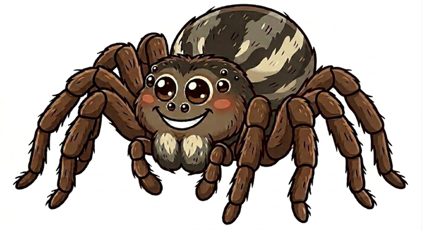

First get the data and fit the logistic regression model:

```r
spider <- read_csv("https://tjfisher19.github.io/data/spiderCannibalism.csv",
                   show_col_types=FALSE)

spider_fit <- glm(Cannibalism ~ SizeDiff,
                  data=spider,
                  family=binomial(link=logit))
summary(spider_fit)
```

```
Call:
glm(formula = Cannibalism ~ SizeDiff, family = binomial(link = logit),
    data = spider)

Coefficients:
            Estimate Std. Error z value Pr(>|z|)
(Intercept)  -3.0890     0.8288  -3.727 0.000194 ***
SizeDiff      3.0693     1.0041   3.057 0.002237 **
---
Signif. codes:  0 '***' 0.001 '**' 0.01 '*' 0.05 '.' 0.1 ' ' 1

(Dispersion parameter for binomial family taken to be 1)

    Null deviance: 53.663  on 51  degrees of freedom
Residual deviance: 34.721  on 50  degrees of freedom
AIC: 38.721

Number of Fisher Scoring iterations: 6
```

We will perform a test for overall model significance:

```r
spider_null <- glm(Cannibalism ~ 1,
                   data=spider, family=binomial(link=logit))
anova(spider_null, spider_fit)
```

```
Analysis of Deviance Table

Model 1: Cannibalism ~ 1
Model 2: Cannibalism ~ SizeDiff
  Resid. Df Resid. Dev Df Deviance  Pr(>Chi)
1        51     53.663
2        50     34.721  1   18.942 1.348e-05 ***
---
Signif. codes:  0 '***' 0.001 '**' 0.01 '*' 0.05 '.' 0.1 ' ' 1
```

With a $\chi^2$ value of 18.942 on 1 degree of freedom $p$-value=1.3^{-5}, we have significance evidence that the model with size difference between female and male spiders significantly predicts the log odds of postmating cannibalism occurring.

We also get this same result using the `drop1()` function since there is only a single predictor variable:

```r
drop1(spider_fit, test="LRT")
```

```
Single term deletions

Model:
Cannibalism ~ SizeDiff
         Df Deviance    AIC    LRT  Pr(>Chi)
<none>        34.721 38.721
SizeDiff  1   53.663 55.663 18.942 1.348e-05 ***
---
Signif. codes:  0 '***' 0.001 '**' 0.01 '*' 0.05 '.' 0.1 ' ' 1
```

**Note**

Note that this LRT test provides a different $p$-value than the one provided by the Wald test in `summary()`. The Wald test $p$-value is larger because the test is known to be conservative (less likely to reject the null hypothesis).

We also see that the model explains approximately 35.3 percent of the deviance in the likelihood of spider cannibalism (using the Pseudo $R^2$).

Furthermore, the ratio of the residual deviance to its degrees of freedom is 0.6944181 which is less than 1, suggesting a reasonably appropriate model fit.

## Model Prediction

Suppose we wished to make predictions using our model, we can do so with the `predict()` function:

```r
predict(spider_fit)
```

```
          1           2           3           4           5           6
-6.15832532 -6.15832532 -5.54446913 -5.54446913 -4.93061295 -4.93061295
          7           8           9          10          11          12
-4.31675676 -4.31675676 -4.31675676 -4.31675676 -3.70290058 -3.70290058
         13          14          15          16          17          18
-3.70290058 -3.70290058 -3.08904439 -3.08904439 -3.08904439 -3.08904439
         19          20          21          22          23          24
-3.08904439 -3.08904439 -2.47518821 -2.47518821 -2.47518821 -2.47518821
         25          26          27          28          29          30
-2.47518821 -2.47518821 -1.86133202 -1.86133202 -1.86133202 -1.86133202
         31          32          33          34          35          36
-1.86133202 -1.24747584 -1.24747584 -1.24747584 -1.24747584 -1.24747584
         37          38          39          40          41          42
-1.24747584 -1.24747584 -0.63361965 -0.63361965 -0.63361965 -0.63361965
         43          44          45          46          47          48
-0.63361965 -0.01976346 -0.01976346 -0.01976346 -0.01976346  0.59409272
         49          50          51          52
 1.20794891  1.82180509  2.43566128  3.04951746
```

The output here are the **model-predicted log-odds of cannibalism** for each of the individual data points (see both negative and positive values because we are working with log-odds). We can get predicted probabilities with a minor change to the code:

```r
predict(spider_fit, type="response")
```

```
          1           2           3           4           5           6
0.002111326 0.002111326 0.003893797 0.003893797 0.007170291 0.007170291
          7           8           9          10          11          12
0.013167395 0.013167395 0.013167395 0.013167395 0.024058822 0.024058822
         13          14          15          16          17          18
0.024058822 0.024058822 0.043561432 0.043561432 0.043561432 0.043561432
         19          20          21          22          23          24
0.043561432 0.043561432 0.077615987 0.077615987 0.077615987 0.077615987
         25          26          27          28          29          30
0.077615987 0.077615987 0.134547870 0.134547870 0.134547870 0.134547870
         31          32          33          34          35          36
0.134547870 0.223137390 0.223137390 0.223137390 0.223137390 0.223137390
         37          38          39          40          41          42
0.223137390 0.223137390 0.346690247 0.346690247 0.346690247 0.346690247
         43          44          45          46          47          48
0.346690247 0.495059295 0.495059295 0.495059295 0.495059295 0.644303654
         49          50          51          52
0.769935830 0.860782583 0.919506544 0.954761689
```

Now all values are between 0 and 1 and correspond to the probability of postmating cannibalism occurring for all the size difference in the dataset.

### Plotting a Logistic Curve

A logistic function is a smooth S-curve. If we plotted the above values it would take the correct shape but look fairly jagged. To get a smooth curve we can create a new dataset with many `SizeDiff` values (over a much finer grid than the original data) and then `predict()` these values. By default, `predict()` outputs logs of odds, so we specify `type="response"` to get probabilities. This is the same techniques we used in Linear Regression Lecture 02 when we plotted data on a logarithmic scale.

```r
spider.fit.plot.data <- data.frame(SizeDiff=seq(-1.2, 2.2, 0.01))
spider.fit.plot.data <- spider.fit.plot.data |>
  mutate(Predicted.Prob = predict(spider_fit, newdata=spider.fit.plot.data, type="response"))

glimpse(spider.fit.plot.data)
```

```
Rows: 341
Columns: 2
$ SizeDiff       <dbl> -1.20, -1.19, -1.18, -1.17, -1.16, -1.15, -1.14, -1.13,…
$ Predicted.Prob <dbl> 0.001143884, 0.001179495, 0.001216214, 0.001254074, 0.0…
```

Note the steps in the `SizeDiff` variable, changes by only 0.01 mm. Now, we can make a plot of the fitted model.

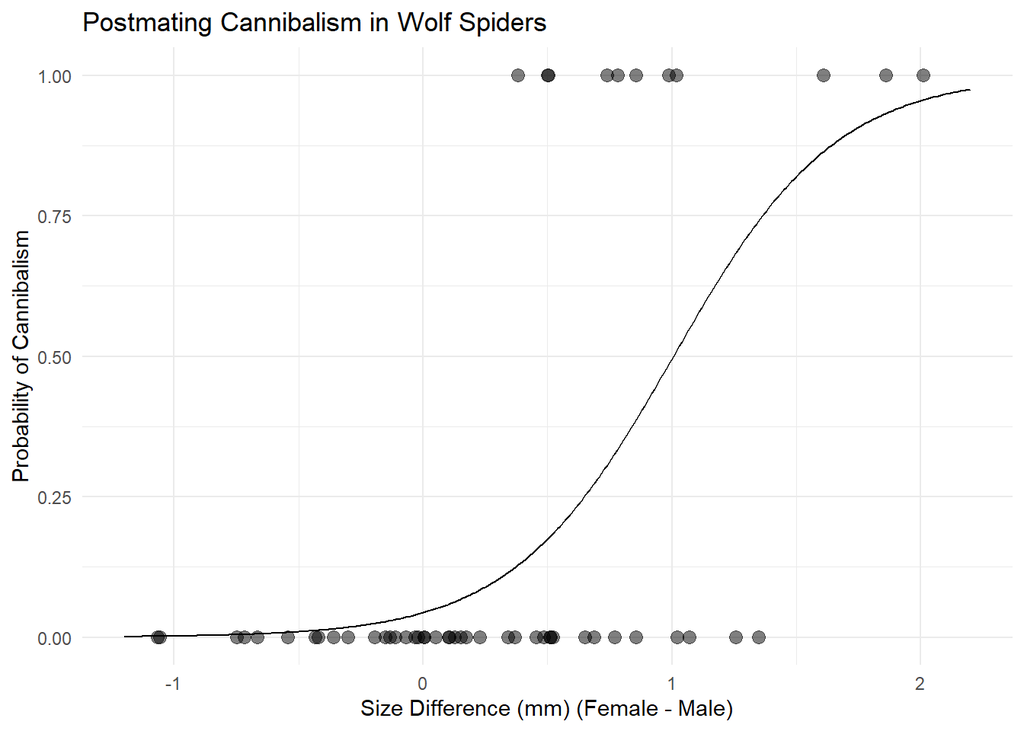

```r
ggplot() +
  geom_jitter(data=spider,
              aes(x=SizeDiff, y=Cannibalism),
              height=0, width=0.1, alpha=0.5, size=2.75) +
  geom_line(data=spider.fit.plot.data, aes(x=SizeDiff, y=Predicted.Prob)) +
  labs(x="Size Difference (mm) (Female - Male)",
       y="Probability of Cannibalism",
       title="Postmating Cannibalism in Wolf Spiders") +
  theme_minimal()
```

### Predicting with Confidence

Predicting the output with some level of confidence is a little trickier with generalized linear models. This is because generalized linear models are essentially fitting models on transformed parameters, so the entire interval needs to be “un-transformed.”

Suppose we wished to get an interval for the probability of postmating cannibalism when the size difference between the female and male spider is 1 mm. We can get the necessary information from the `predict()` function but then we will need to do some math.

```r
Spider_Example <- data.frame(SizeDiff = 1)

predict(spider_fit, newdata=Spider_Example, se.fit = TRUE)
```

```
$fit
          1
-0.01976346

$se.fit
[1] 0.5211059

$residual.scale
[1] 1
```

Using the predicted value and the associated standard error we can use Standard Normal techniques (recall the one-sample confidence interval from Intro Stat) to build an interval for the predicted log-odds. Then use the inverse logit function to get a predicted probability.

```r
predict_out <- predict(spider_fit, newdata=Spider_Example, se.fit = TRUE)

log_odds_interval <- predict_out$fit + c(-1,1)*1.96*predict_out$se.fit

log_odds_interval
```

```
[1] -1.041131  1.001604
```

```r
exp(log_odds_interval)/(1 + exp(log_odds_interval))
```

```
[1] 0.2609318 0.7313739
```

With 95% confidence, we predict the probability of postmating cannibalism occurring when the size difference between female and male spiders is 1 mm is between 0.26 and 0.73.

### Confidence Bands

Using the above technique of building an interval around the log-odds prediction, and then transforming to probabilities, we can build a confidence band around the entire logistic curve. In the code chunk that follows we use methods for fitting nonlinear models and confidence bands (see Linear Regression Lecture 04).

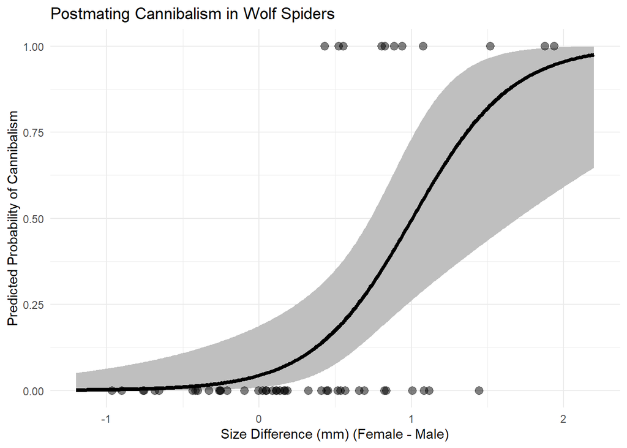

```r
## Same Idea as above
spider.fit.plot.data <- data.frame(SizeDiff=seq(-1.2, 2.2, 0.01))

spider.fit.plot.data <- spider.fit.plot.data |>
  mutate(Pred_log_odds = predict(spider_fit, newdata=spider.fit.plot.data, se.fit=TRUE)$fit,
         Pred_SE = predict(spider_fit, newdata=spider.fit.plot.data, se.fit=TRUE)$se)

## Now confidence bands, and convert from log-odds to probability
spider.fit.plot.data <- spider.fit.plot.data |>
  mutate(Pred_log_odds_lo = Pred_log_odds - 1.96*Pred_SE,
         Pred_log_odds_hi = Pred_log_odds + 1.96*Pred_SE,
         Pred_Prob = family(spider_fit)$linkinv(Pred_log_odds),
         Pred_Prob_lo = family(spider_fit)$linkinv(Pred_log_odds_lo),
         Pred_Prob_hi = family(spider_fit)$linkinv(Pred_log_odds_hi))

## Now use geom_ribbon() for the confidence bands
ggplot(spider.fit.plot.data) +
  geom_ribbon(aes(x=SizeDiff, ymin=Pred_Prob_lo, ymax=Pred_Prob_hi), fill="gray75" ) +
  geom_line(aes(x=SizeDiff, y=Pred_Prob), linewidth=1.5) +
  geom_jitter(data=spider, aes(x=SizeDiff, y=Cannibalism),
              height=0, width=0.1, alpha=0.5, size=2.75) +
  theme_minimal() +
  labs(x="Size Difference (mm) (Female - Male)",
       y="Predicted Probability of Cannibalism",
       title="Postmating Cannibalism in Wolf Spiders")
```

In the plot above we see the predicted probability the male spider is consumed as a function of the size difference while also reporting the 95% confidence bands on the fitted model.

**Note**

Note that the confidence bands are wider for larger size difference values. This is because we have less data for larger size differences (*e.g*, about 2mm), so there is more room for error, and thus a wider interval.

## References

Brener, Nancy D., Jonetta J. Mpofu, Kathleen H. Krause, Sherry Everett Jones, Jemekia E. Thornton, Zachary Myles, William A. Harris, et al. 2024. “Overview and Methods for the Youth Risk Behavior Surveillance System — United States, 2023.” *MMWR Supplements* 73 (4): 1–12. https://doi.org/10.15585/mmwr.su7304a1.

Centers for Disease Control and Prevention. 2024. “2023 Youth Risk Behavior Survey Data.” Atlanta, GA: CDC Website.

Gemini. 2026. “Interaction with Gemini: AI-Generated Clip Art and Marketing Graphics.” Google Gemini (Web Version).

Peck, R., C. Olsen, and J. L. Devore. 2011. *Introduction to Statistics and Data Analysis*. Cengage Learning.

Persons, Matthew H., and George W. Uetz. 2005. “Sexual Cannibalism and Mate Choice Decisions in Wolf Spiders: Influence of Male Size and Secondary Sexual Characters.” *Animal Behaviour* 69 (1): 83–94. https://doi.org/https://doi.org/10.1016/j.anbehav.2003.12.030.